# Risk Factor Analysis

## Outcome Variable

**Outcome Variable:** sstunted

## Predictor Variables

**Intervention Variable:** single

**Adjustment Set:**

unadjusted

## Stratifying Variables

The analysis was stratified on these variable(s):

- agecat
- studyid
- country

## Data Summary

| agecat | studyid | country | A | n | nA | nAY0 | nAY1 |
| --- | --- | --- | --- | --- | --- | --- | --- |
| Birth | ki0047075b-MAL-ED | BANGLADESH | 0 | 257 | 257 | 248 | 9 |
| Birth | ki0047075b-MAL-ED | BANGLADESH | 1 | 257 | 0 | 0 | 0 |
| Birth | ki0047075b-MAL-ED | BRAZIL | 0 | 191 | 166 | 160 | 6 |
| Birth | ki0047075b-MAL-ED | BRAZIL | 1 | 191 | 25 | 23 | 2 |
| Birth | ki0047075b-MAL-ED | INDIA | 0 | 205 | 205 | 198 | 7 |
| Birth | ki0047075b-MAL-ED | INDIA | 1 | 205 | 0 | 0 | 0 |
| Birth | ki0047075b-MAL-ED | NEPAL | 0 | 173 | 173 | 167 | 6 |
| Birth | ki0047075b-MAL-ED | NEPAL | 1 | 173 | 0 | 0 | 0 |
| Birth | ki0047075b-MAL-ED | PERU | 0 | 287 | 253 | 247 | 6 |
| Birth | ki0047075b-MAL-ED | PERU | 1 | 287 | 34 | 32 | 2 |
| Birth | ki0047075b-MAL-ED | SOUTH AFRICA | 0 | 262 | 146 | 146 | 0 |
| Birth | ki0047075b-MAL-ED | SOUTH AFRICA | 1 | 262 | 116 | 114 | 2 |
| Birth | ki0047075b-MAL-ED | TANZANIA, UNITED REPUBLIC OF | 0 | 123 | 117 | 111 | 6 |
| Birth | ki0047075b-MAL-ED | TANZANIA, UNITED REPUBLIC OF | 1 | 123 | 6 | 6 | 0 |
| Birth | ki1119695-PROBIT | BELARUS | 0 | 6779 | 6540 | 6535 | 5 |
| Birth | ki1119695-PROBIT | BELARUS | 1 | 6779 | 239 | 239 | 0 |
| Birth | ki1126311-ZVITAMBO | ZIMBABWE | 0 | 13772 | 12902 | 12496 | 406 |
| Birth | ki1126311-ZVITAMBO | ZIMBABWE | 1 | 13772 | 870 | 838 | 32 |
| Birth | ki1135781-COHORTS | GUATEMALA | 0 | 363 | 334 | 332 | 2 |
| Birth | ki1135781-COHORTS | GUATEMALA | 1 | 363 | 29 | 29 | 0 |
| Birth | ki1135781-COHORTS | INDIA | 0 | 4778 | 4771 | 4630 | 141 |
| Birth | ki1135781-COHORTS | INDIA | 1 | 4778 | 7 | 7 | 0 |
| Birth | ki1135781-COHORTS | PHILIPPINES | 0 | 3010 | 2936 | 2893 | 43 |
| Birth | ki1135781-COHORTS | PHILIPPINES | 1 | 3010 | 74 | 72 | 2 |
| 3 months | ki0047075b-MAL-ED | BANGLADESH | 0 | 250 | 250 | 243 | 7 |
| 3 months | ki0047075b-MAL-ED | BANGLADESH | 1 | 250 | 0 | 0 | 0 |
| 3 months | ki0047075b-MAL-ED | BRAZIL | 0 | 225 | 191 | 191 | 0 |
| 3 months | ki0047075b-MAL-ED | BRAZIL | 1 | 225 | 34 | 33 | 1 |
| 3 months | ki0047075b-MAL-ED | INDIA | 0 | 239 | 239 | 229 | 10 |
| 3 months | ki0047075b-MAL-ED | INDIA | 1 | 239 | 0 | 0 | 0 |

[output cut: 156 more lines]

The following strata were considered:

- agecat: 12 months, studyid: ki0047075b-MAL-ED, country: BANGLADESH
- agecat: 12 months, studyid: ki0047075b-MAL-ED, country: BRAZIL
- agecat: 12 months, studyid: ki0047075b-MAL-ED, country: INDIA
- agecat: 12 months, studyid: ki0047075b-MAL-ED, country: NEPAL
- agecat: 12 months, studyid: ki0047075b-MAL-ED, country: PERU
- agecat: 12 months, studyid: ki0047075b-MAL-ED, country: SOUTH AFRICA
- agecat: 12 months, studyid: ki0047075b-MAL-ED, country: TANZANIA, UNITED REPUBLIC OF
- agecat: 12 months, studyid: ki1066203-TanzaniaChild2, country: TANZANIA, UNITED REPUBLIC OF
- agecat: 12 months, studyid: ki1112895-Guatemala BSC, country: GUATEMALA
- agecat: 12 months, studyid: ki1119695-PROBIT, country: BELARUS
- agecat: 12 months, studyid: ki1126311-ZVITAMBO, country: ZIMBABWE
- agecat: 12 months, studyid: ki1135781-COHORTS, country: GUATEMALA
- agecat: 12 months, studyid: ki1135781-COHORTS, country: INDIA
- agecat: 12 months, studyid: ki1135781-COHORTS, country: PHILIPPINES
- agecat: 18 months, studyid: ki0047075b-MAL-ED, country: BANGLADESH
- agecat: 18 months, studyid: ki0047075b-MAL-ED, country: BRAZIL
- agecat: 18 months, studyid: ki0047075b-MAL-ED, country: INDIA
- agecat: 18 months, studyid: ki0047075b-MAL-ED, country: NEPAL
- agecat: 18 months, studyid: ki0047075b-MAL-ED, country: PERU
- agecat: 18 months, studyid: ki0047075b-MAL-ED, country: SOUTH AFRICA
- agecat: 18 months, studyid: ki0047075b-MAL-ED, country: TANZANIA, UNITED REPUBLIC OF
- agecat: 18 months, studyid: ki1066203-TanzaniaChild2, country: TANZANIA, UNITED REPUBLIC OF
- agecat: 18 months, studyid: ki1119695-PROBIT, country: BELARUS
- agecat: 18 months, studyid: ki1126311-ZVITAMBO, country: ZIMBABWE
- agecat: 18 months, studyid: ki1135781-COHORTS, country: GUATEMALA
- agecat: 18 months, studyid: ki1135781-COHORTS, country: PHILIPPINES
- agecat: 24 months, studyid: ki0047075b-MAL-ED, country: BANGLADESH
- agecat: 24 months, studyid: ki0047075b-MAL-ED, country: BRAZIL
- agecat: 24 months, studyid: ki0047075b-MAL-ED, country: INDIA
- agecat: 24 months, studyid: ki0047075b-MAL-ED, country: NEPAL
- agecat: 24 months, studyid: ki0047075b-MAL-ED, country: PERU
- agecat: 24 months, studyid: ki0047075b-MAL-ED, country: SOUTH AFRICA
- agecat: 24 months, studyid: ki0047075b-MAL-ED, country: TANZANIA, UNITED REPUBLIC OF
- agecat: 24 months, studyid: ki1066203-TanzaniaChild2, country: TANZANIA, UNITED REPUBLIC OF
- agecat: 24 months, studyid: ki1119695-PROBIT, country: BELARUS
- agecat: 24 months, studyid: ki1126311-ZVITAMBO, country: ZIMBABWE
- agecat: 24 months, studyid: ki1135781-COHORTS, country: GUATEMALA
- agecat: 24 months, studyid: ki1135781-COHORTS, country: INDIA
- agecat: 24 months, studyid: ki1135781-COHORTS, country: PHILIPPINES
- agecat: 3 months, studyid: ki0047075b-MAL-ED, country: BANGLADESH
- agecat: 3 months, studyid: ki0047075b-MAL-ED, country: BRAZIL
- agecat: 3 months, studyid: ki0047075b-MAL-ED, country: INDIA
- agecat: 3 months, studyid: ki0047075b-MAL-ED, country: NEPAL
- agecat: 3 months, studyid: ki0047075b-MAL-ED, country: PERU
- agecat: 3 months, studyid: ki0047075b-MAL-ED, country: SOUTH AFRICA
- agecat: 3 months, studyid: ki0047075b-MAL-ED, country: TANZANIA, UNITED REPUBLIC OF
- agecat: 3 months, studyid: ki1066203-TanzaniaChild2, country: TANZANIA, UNITED REPUBLIC OF
- agecat: 3 months, studyid: ki1112895-Guatemala BSC, country: GUATEMALA
- agecat: 3 months, studyid: ki1119695-PROBIT, country: BELARUS
- agecat: 3 months, studyid: ki1126311-ZVITAMBO, country: ZIMBABWE
- agecat: 3 months, studyid: ki1135781-COHORTS, country: GUATEMALA
- agecat: 3 months, studyid: ki1135781-COHORTS, country: INDIA
- agecat: 3 months, studyid: ki1135781-COHORTS, country: PHILIPPINES
- agecat: 6 months, studyid: ki0047075b-MAL-ED, country: BANGLADESH
- agecat: 6 months, studyid: ki0047075b-MAL-ED, country: BRAZIL
- agecat: 6 months, studyid: ki0047075b-MAL-ED, country: INDIA
- agecat: 6 months, studyid: ki0047075b-MAL-ED, country: NEPAL
- agecat: 6 months, studyid: ki0047075b-MAL-ED, country: PERU
- agecat: 6 months, studyid: ki0047075b-MAL-ED, country: SOUTH AFRICA
- agecat: 6 months, studyid: ki0047075b-MAL-ED, country: TANZANIA, UNITED REPUBLIC OF
- agecat: 6 months, studyid: ki1066203-TanzaniaChild2, country: TANZANIA, UNITED REPUBLIC OF
- agecat: 6 months, studyid: ki1112895-Guatemala BSC, country: GUATEMALA
- agecat: 6 months, studyid: ki1119695-PROBIT, country: BELARUS
- agecat: 6 months, studyid: ki1126311-ZVITAMBO, country: ZIMBABWE
- agecat: 6 months, studyid: ki1135781-COHORTS, country: GUATEMALA
- agecat: 6 months, studyid: ki1135781-COHORTS, country: INDIA
- agecat: 6 months, studyid: ki1135781-COHORTS, country: PHILIPPINES
- agecat: 9 months, studyid: ki0047075b-MAL-ED, country: BANGLADESH
- agecat: 9 months, studyid: ki0047075b-MAL-ED, country: BRAZIL
- agecat: 9 months, studyid: ki0047075b-MAL-ED, country: INDIA
- agecat: 9 months, studyid: ki0047075b-MAL-ED, country: NEPAL
- agecat: 9 months, studyid: ki0047075b-MAL-ED, country: PERU
- agecat: 9 months, studyid: ki0047075b-MAL-ED, country: SOUTH AFRICA
- agecat: 9 months, studyid: ki0047075b-MAL-ED, country: TANZANIA, UNITED REPUBLIC OF
- agecat: 9 months, studyid: ki1066203-TanzaniaChild2, country: TANZANIA, UNITED REPUBLIC OF
- agecat: 9 months, studyid: ki1112895-Guatemala BSC, country: GUATEMALA
- agecat: 9 months, studyid: ki1119695-PROBIT, country: BELARUS
- agecat: 9 months, studyid: ki1126311-ZVITAMBO, country: ZIMBABWE
- agecat: 9 months, studyid: ki1135781-COHORTS, country: GUATEMALA
- agecat: 9 months, studyid: ki1135781-COHORTS, country: INDIA
- agecat: 9 months, studyid: ki1135781-COHORTS, country: PHILIPPINES
- agecat: Birth, studyid: ki0047075b-MAL-ED, country: BANGLADESH
- agecat: Birth, studyid: ki0047075b-MAL-ED, country: BRAZIL
- agecat: Birth, studyid: ki0047075b-MAL-ED, country: INDIA
- agecat: Birth, studyid: ki0047075b-MAL-ED, country: NEPAL
- agecat: Birth, studyid: ki0047075b-MAL-ED, country: PERU
- agecat: Birth, studyid: ki0047075b-MAL-ED, country: SOUTH AFRICA
- agecat: Birth, studyid: ki0047075b-MAL-ED, country: TANZANIA, UNITED REPUBLIC OF
- agecat: Birth, studyid: ki1119695-PROBIT, country: BELARUS
- agecat: Birth, studyid: ki1126311-ZVITAMBO, country: ZIMBABWE
- agecat: Birth, studyid: ki1135781-COHORTS, country: GUATEMALA
- agecat: Birth, studyid: ki1135781-COHORTS, country: INDIA
- agecat: Birth, studyid: ki1135781-COHORTS, country: PHILIPPINES

### Dropped Strata

Some strata were dropped due to rare outcomes:

- agecat: Birth, studyid: ki0047075b-MAL-ED, country: BANGLADESH
- agecat: Birth, studyid: ki0047075b-MAL-ED, country: BRAZIL
- agecat: Birth, studyid: ki0047075b-MAL-ED, country: INDIA
- agecat: Birth, studyid: ki0047075b-MAL-ED, country: NEPAL
- agecat: Birth, studyid: ki0047075b-MAL-ED, country: PERU
- agecat: Birth, studyid: ki0047075b-MAL-ED, country: SOUTH AFRICA
- agecat: Birth, studyid: ki0047075b-MAL-ED, country: TANZANIA, UNITED REPUBLIC OF
- agecat: Birth, studyid: ki1119695-PROBIT, country: BELARUS
- agecat: Birth, studyid: ki1135781-COHORTS, country: GUATEMALA
- agecat: Birth, studyid: ki1135781-COHORTS, country: INDIA
- agecat: Birth, studyid: ki1135781-COHORTS, country: PHILIPPINES
- agecat: 3 months, studyid: ki0047075b-MAL-ED, country: BANGLADESH
- agecat: 3 months, studyid: ki0047075b-MAL-ED, country: BRAZIL
- agecat: 3 months, studyid: ki0047075b-MAL-ED, country: INDIA
- agecat: 3 months, studyid: ki0047075b-MAL-ED, country: NEPAL
- agecat: 3 months, studyid: ki0047075b-MAL-ED, country: PERU
- agecat: 3 months, studyid: ki0047075b-MAL-ED, country: SOUTH AFRICA
- agecat: 3 months, studyid: ki0047075b-MAL-ED, country: TANZANIA, UNITED REPUBLIC OF
- agecat: 3 months, studyid: ki1066203-TanzaniaChild2, country: TANZANIA, UNITED REPUBLIC OF
- agecat: 3 months, studyid: ki1112895-Guatemala BSC, country: GUATEMALA
- agecat: 3 months, studyid: ki1135781-COHORTS, country: INDIA
- agecat: 3 months, studyid: ki1135781-COHORTS, country: PHILIPPINES
- agecat: 6 months, studyid: ki0047075b-MAL-ED, country: BANGLADESH
- agecat: 6 months, studyid: ki0047075b-MAL-ED, country: BRAZIL
- agecat: 6 months, studyid: ki0047075b-MAL-ED, country: INDIA
- agecat: 6 months, studyid: ki0047075b-MAL-ED, country: NEPAL
- agecat: 6 months, studyid: ki0047075b-MAL-ED, country: PERU
- agecat: 6 months, studyid: ki0047075b-MAL-ED, country: SOUTH AFRICA
- agecat: 6 months, studyid: ki0047075b-MAL-ED, country: TANZANIA, UNITED REPUBLIC OF
- agecat: 6 months, studyid: ki1066203-TanzaniaChild2, country: TANZANIA, UNITED REPUBLIC OF
- agecat: 6 months, studyid: ki1135781-COHORTS, country: INDIA
- agecat: 6 months, studyid: ki1135781-COHORTS, country: PHILIPPINES
- agecat: 9 months, studyid: ki0047075b-MAL-ED, country: BANGLADESH
- agecat: 9 months, studyid: ki0047075b-MAL-ED, country: BRAZIL
- agecat: 9 months, studyid: ki0047075b-MAL-ED, country: INDIA
- agecat: 9 months, studyid: ki0047075b-MAL-ED, country: NEPAL
- agecat: 9 months, studyid: ki0047075b-MAL-ED, country: SOUTH AFRICA
- agecat: 9 months, studyid: ki0047075b-MAL-ED, country: TANZANIA, UNITED REPUBLIC OF
- agecat: 9 months, studyid: ki1066203-TanzaniaChild2, country: TANZANIA, UNITED REPUBLIC OF
- agecat: 9 months, studyid: ki1135781-COHORTS, country: INDIA
- agecat: 9 months, studyid: ki1135781-COHORTS, country: PHILIPPINES
- agecat: 12 months, studyid: ki0047075b-MAL-ED, country: BANGLADESH
- agecat: 12 months, studyid: ki0047075b-MAL-ED, country: BRAZIL
- agecat: 12 months, studyid: ki0047075b-MAL-ED, country: INDIA
- agecat: 12 months, studyid: ki0047075b-MAL-ED, country: NEPAL
- agecat: 12 months, studyid: ki0047075b-MAL-ED, country: PERU
- agecat: 12 months, studyid: ki0047075b-MAL-ED, country: TANZANIA, UNITED REPUBLIC OF
- agecat: 12 months, studyid: ki1066203-TanzaniaChild2, country: TANZANIA, UNITED REPUBLIC OF
- agecat: 12 months, studyid: ki1119695-PROBIT, country: BELARUS
- agecat: 12 months, studyid: ki1135781-COHORTS, country: INDIA
- agecat: 18 months, studyid: ki0047075b-MAL-ED, country: BANGLADESH
- agecat: 18 months, studyid: ki0047075b-MAL-ED, country: BRAZIL
- agecat: 18 months, studyid: ki0047075b-MAL-ED, country: INDIA
- agecat: 18 months, studyid: ki0047075b-MAL-ED, country: NEPAL
- agecat: 18 months, studyid: ki0047075b-MAL-ED, country: TANZANIA, UNITED REPUBLIC OF
- agecat: 18 months, studyid: ki1119695-PROBIT, country: BELARUS
- agecat: 24 months, studyid: ki0047075b-MAL-ED, country: BANGLADESH
- agecat: 24 months, studyid: ki0047075b-MAL-ED, country: BRAZIL
- agecat: 24 months, studyid: ki0047075b-MAL-ED, country: INDIA
- agecat: 24 months, studyid: ki0047075b-MAL-ED, country: NEPAL
- agecat: 24 months, studyid: ki0047075b-MAL-ED, country: PERU
- agecat: 24 months, studyid: ki0047075b-MAL-ED, country: TANZANIA, UNITED REPUBLIC OF
- agecat: 24 months, studyid: ki1066203-TanzaniaChild2, country: TANZANIA, UNITED REPUBLIC OF
- agecat: 24 months, studyid: ki1119695-PROBIT, country: BELARUS
- agecat: 24 months, studyid: ki1135781-COHORTS, country: INDIA

## Methods Detail

We’re interested in the causal parameters $E[Y_a]$ for all values of $a \in \mathcal{A}$. These parameters represent the mean outcome if, possibly contrary to fact, we intervened to set all units to have $A=a$. Under the randomization and positivity assumptions, these are identified by the statistical parameters $\psi_a=E_W[E_{Y|A,W}(Y|A=a,W)]$. In addition, we’re interested in the mean of $Y$, $E[Y]$ under no intervention (the observed mean). We will estimate these parameters by using SuperLearner to fit the relevant likelihood factors – $E_{Y|A,W}(Y|A=a,W)$ and $p(A=a|W)$, and then updating our likelihood fit using a joint TMLE.

For unadjusted analyses ($W=\{\}$), initial likelihoods were estimated using Lrnr_glm to estimate the simple $E(Y|A)$ and Lrnr_mean to estimate $p(A)$. For adjusted analyses, a small library containing Lrnr_glmnet, Lrnr_xgboost, and Lrnr_mean was used.

Having estimated these parameters, we will then use the delta method to estimate relative risks and attributable risks relative to a prespecified baseline level of $A$.

# Results Detail

## Results Plots

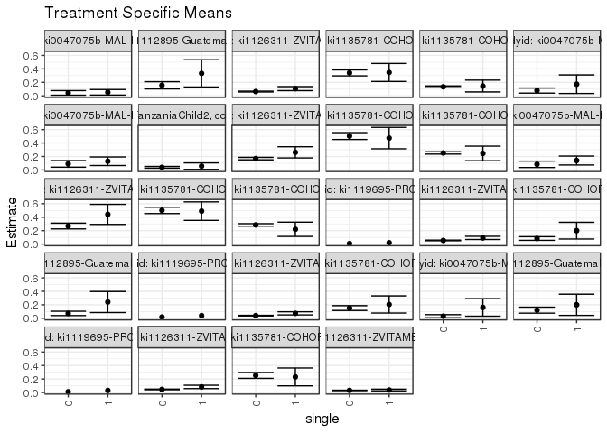

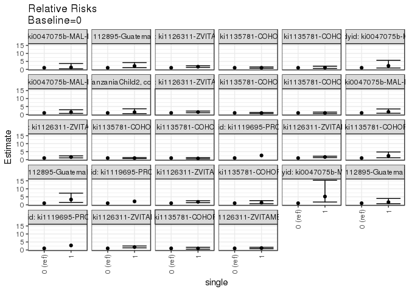

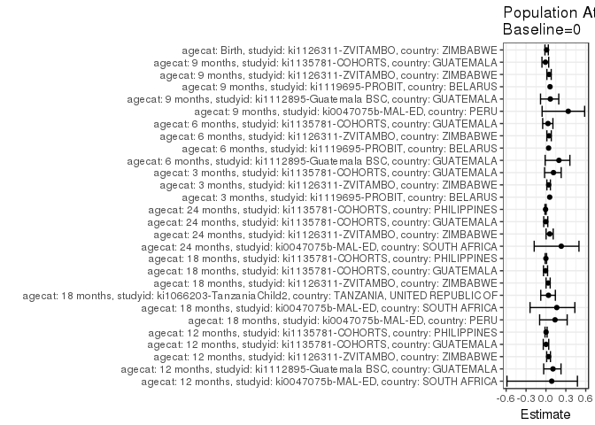

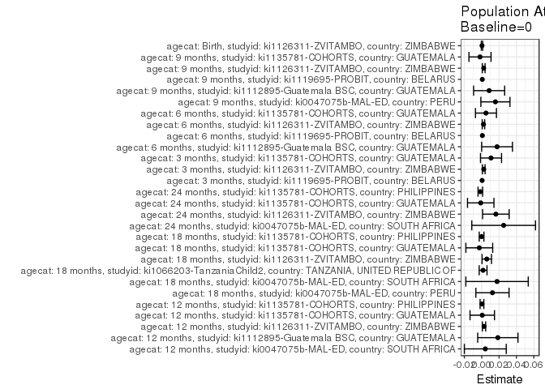

## Results Table

### Parameter: TSM

| agecat | studyid | country | intervention_level | baseline_level | estimate | ci_lower | ci_upper |
| --- | --- | --- | --- | --- | --- | --- | --- |
| Birth | ki1126311-ZVITAMBO | ZIMBABWE | 0 | NA | 0.0314680 | 0.0284555 | 0.0344805 |
| Birth | ki1126311-ZVITAMBO | ZIMBABWE | 1 | NA | 0.0367816 | 0.0242738 | 0.0492894 |
| 3 months | ki1119695-PROBIT | BELARUS | 0 | NA | 0.0077290 | NA | NA |
| 3 months | ki1119695-PROBIT | BELARUS | 1 | NA | 0.0204082 | NA | NA |
| 3 months | ki1126311-ZVITAMBO | ZIMBABWE | 0 | NA | 0.0548695 | 0.0500518 | 0.0596872 |
| 3 months | ki1126311-ZVITAMBO | ZIMBABWE | 1 | NA | 0.0923345 | 0.0686502 | 0.1160188 |
| 3 months | ki1135781-COHORTS | GUATEMALA | 0 | NA | 0.0837563 | 0.0563712 | 0.1111415 |
| 3 months | ki1135781-COHORTS | GUATEMALA | 1 | NA | 0.2000000 | 0.0758979 | 0.3241021 |
| 6 months | ki1112895-Guatemala BSC | GUATEMALA | 0 | NA | 0.0725806 | 0.0402320 | 0.1049293 |
| 6 months | ki1112895-Guatemala BSC | GUATEMALA | 1 | NA | 0.2413793 | 0.0853534 | 0.3974052 |
| 6 months | ki1119695-PROBIT | BELARUS | 0 | NA | 0.0182803 | NA | NA |
| 6 months | ki1119695-PROBIT | BELARUS | 1 | NA | 0.0392857 | NA | NA |
| 6 months | ki1126311-ZVITAMBO | ZIMBABWE | 0 | NA | 0.0397428 | 0.0354002 | 0.0440853 |
| 6 months | ki1126311-ZVITAMBO | ZIMBABWE | 1 | NA | 0.0734694 | 0.0503669 | 0.0965719 |
| 6 months | ki1135781-COHORTS | GUATEMALA | 0 | NA | 0.1516710 | 0.1159836 | 0.1873583 |
| 6 months | ki1135781-COHORTS | GUATEMALA | 1 | NA | 0.2051282 | 0.0782506 | 0.3320058 |
| 9 months | ki0047075b-MAL-ED | PERU | 0 | NA | 0.0311111 | 0.0083810 | 0.0538412 |
| 9 months | ki0047075b-MAL-ED | PERU | 1 | NA | 0.1612903 | 0.0315643 | 0.2910163 |
| 9 months | ki1112895-Guatemala BSC | GUATEMALA | 0 | NA | 0.1207729 | 0.0762856 | 0.1652603 |
| 9 months | ki1112895-Guatemala BSC | GUATEMALA | 1 | NA | 0.2000000 | 0.0428639 | 0.3571361 |
| 9 months | ki1119695-PROBIT | BELARUS | 0 | NA | 0.0105336 | NA | NA |
| 9 months | ki1119695-PROBIT | BELARUS | 1 | NA | 0.0298507 | NA | NA |
| 9 months | ki1126311-ZVITAMBO | ZIMBABWE | 0 | NA | 0.0457270 | 0.0408926 | 0.0505615 |
| 9 months | ki1126311-ZVITAMBO | ZIMBABWE | 1 | NA | 0.0826271 | 0.0577878 | 0.1074664 |
| 9 months | ki1135781-COHORTS | GUATEMALA | 0 | NA | 0.2525773 | 0.2092939 | 0.2958608 |
| 9 months | ki1135781-COHORTS | GUATEMALA | 1 | NA | 0.2307692 | 0.0983832 | 0.3631553 |
| 12 months | ki0047075b-MAL-ED | SOUTH AFRICA | 0 | NA | 0.0434783 | 0.0093860 | 0.0775705 |
| 12 months | ki0047075b-MAL-ED | SOUTH AFRICA | 1 | NA | 0.0526316 | 0.0115600 | 0.0937032 |
| 12 months | ki1112895-Guatemala BSC | GUATEMALA | 0 | NA | 0.1564246 | 0.1030758 | 0.2097734 |
| 12 months | ki1112895-Guatemala BSC | GUATEMALA | 1 | NA | 0.3333333 | 0.1312080 | 0.5354586 |
| 12 months | ki1126311-ZVITAMBO | ZIMBABWE | 0 | NA | 0.0635197 | 0.0575029 | 0.0695365 |
| 12 months | ki1126311-ZVITAMBO | ZIMBABWE | 1 | NA | 0.1070560 | 0.0771624 | 0.1369495 |
| 12 months | ki1135781-COHORTS | GUATEMALA | 0 | NA | 0.3409091 | 0.2965729 | 0.3852453 |
| 12 months | ki1135781-COHORTS | GUATEMALA | 1 | NA | 0.3469388 | 0.2135258 | 0.4803517 |
| 12 months | ki1135781-COHORTS | PHILIPPINES | 0 | NA | 0.1335740 | 0.1202173 | 0.1469307 |
| 12 months | ki1135781-COHORTS | PHILIPPINES | 1 | NA | 0.1451613 | 0.0574602 | 0.2328623 |
| 18 months | ki0047075b-MAL-ED | PERU | 0 | NA | 0.0777202 | 0.0398630 | 0.1155774 |
| 18 months | ki0047075b-MAL-ED | PERU | 1 | NA | 0.1724138 | 0.0346224 | 0.3102052 |
| 18 months | ki0047075b-MAL-ED | SOUTH AFRICA | 0 | NA | 0.0902256 | 0.0414326 | 0.1390185 |
| 18 months | ki0047075b-MAL-ED | SOUTH AFRICA | 1 | NA | 0.1296296 | 0.0661487 | 0.1931106 |
| 18 months | ki1066203-TanzaniaChild2 | TANZANIA, UNITED REPUBLIC OF | 0 | NA | 0.0393701 | 0.0265798 | 0.0521604 |
| 18 months | ki1066203-TanzaniaChild2 | TANZANIA, UNITED REPUBLIC OF | 1 | NA | 0.0568182 | 0.0084265 | 0.1052098 |
| 18 months | ki1126311-ZVITAMBO | ZIMBABWE | 0 | NA | 0.1688555 | 0.1504882 | 0.1872229 |
| 18 months | ki1126311-ZVITAMBO | ZIMBABWE | 1 | NA | 0.2616822 | 0.1783732 | 0.3449913 |
| 18 months | ki1135781-COHORTS | GUATEMALA | 0 | NA | 0.5040214 | 0.4532197 | 0.5548232 |
| 18 months | ki1135781-COHORTS | GUATEMALA | 1 | NA | 0.4736842 | 0.3147370 | 0.6326314 |
| 18 months | ki1135781-COHORTS | PHILIPPINES | 0 | NA | 0.2529167 | 0.2355225 | 0.2703108 |
| 18 months | ki1135781-COHORTS | PHILIPPINES | 1 | NA | 0.2459016 | 0.1378165 | 0.3539868 |
| 24 months | ki0047075b-MAL-ED | SOUTH AFRICA | 0 | NA | 0.0839695 | 0.0363765 | 0.1315624 |
| 24 months | ki0047075b-MAL-ED | SOUTH AFRICA | 1 | NA | 0.1401869 | 0.0742655 | 0.2061083 |
| 24 months | ki1126311-ZVITAMBO | ZIMBABWE | 0 | NA | 0.2687651 | 0.2259631 | 0.3115672 |
| 24 months | ki1126311-ZVITAMBO | ZIMBABWE | 1 | NA | 0.4418605 | 0.2932653 | 0.5904556 |
| 24 months | ki1135781-COHORTS | GUATEMALA | 0 | NA | 0.5011494 | 0.4541146 | 0.5481843 |
| 24 months | ki1135781-COHORTS | GUATEMALA | 1 | NA | 0.4901961 | 0.3528562 | 0.6275360 |
| 24 months | ki1135781-COHORTS | PHILIPPINES | 0 | NA | 0.2855325 | 0.2672945 | 0.3037705 |
| 24 months | ki1135781-COHORTS | PHILIPPINES | 1 | NA | 0.2203390 | 0.1145573 | 0.3261207 |

### Parameter: E(Y)

| agecat | studyid | country | intervention_level | baseline_level | estimate | ci_lower | ci_upper |
| --- | --- | --- | --- | --- | --- | --- | --- |
| Birth | ki1126311-ZVITAMBO | ZIMBABWE | NA | NA | 0.0318037 | 0.0288729 | 0.0347345 |
| 3 months | ki1119695-PROBIT | BELARUS | NA | NA | 0.0081916 | NA | NA |
| 3 months | ki1126311-ZVITAMBO | ZIMBABWE | NA | NA | 0.0572177 | 0.0524606 | 0.0619748 |
| 3 months | ki1135781-COHORTS | GUATEMALA | NA | NA | 0.0944700 | 0.0669213 | 0.1220188 |
| 6 months | ki1112895-Guatemala BSC | GUATEMALA | NA | NA | 0.0902527 | 0.0564475 | 0.1240580 |
| 6 months | ki1119695-PROBIT | BELARUS | NA | NA | 0.0190476 | NA | NA |
| 6 months | ki1126311-ZVITAMBO | ZIMBABWE | NA | NA | 0.0417423 | 0.0374303 | 0.0460543 |
| 6 months | ki1135781-COHORTS | GUATEMALA | NA | NA | 0.1565421 | 0.1220768 | 0.1910073 |
| 9 months | ki0047075b-MAL-ED | PERU | NA | NA | 0.0468750 | 0.0209318 | 0.0728182 |
| 9 months | ki1112895-Guatemala BSC | GUATEMALA | NA | NA | 0.1293103 | 0.0860400 | 0.1725807 |
| 9 months | ki1119695-PROBIT | BELARUS | NA | NA | 0.0112254 | NA | NA |
| 9 months | ki1126311-ZVITAMBO | ZIMBABWE | NA | NA | 0.0480052 | 0.0432129 | 0.0527976 |
| 9 months | ki1135781-COHORTS | GUATEMALA | NA | NA | 0.2505855 | 0.2094343 | 0.2917367 |
| 12 months | ki0047075b-MAL-ED | SOUTH AFRICA | NA | NA | 0.0476190 | 0.0212735 | 0.0739646 |
| 12 months | ki1112895-Guatemala BSC | GUATEMALA | NA | NA | 0.1750000 | 0.1222081 | 0.2277919 |
| 12 months | ki1126311-ZVITAMBO | ZIMBABWE | NA | NA | 0.0661808 | 0.0602384 | 0.0721233 |
| 12 months | ki1135781-COHORTS | GUATEMALA | NA | NA | 0.3415133 | 0.2994391 | 0.3835875 |
| 12 months | ki1135781-COHORTS | PHILIPPINES | NA | NA | 0.1338552 | 0.1206498 | 0.1470606 |
| 18 months | ki0047075b-MAL-ED | PERU | NA | NA | 0.0900901 | 0.0523425 | 0.1278377 |
| 18 months | ki0047075b-MAL-ED | SOUTH AFRICA | NA | NA | 0.1078838 | 0.0686346 | 0.1471331 |
| 18 months | ki1066203-TanzaniaChild2 | TANZANIA, UNITED REPUBLIC OF | NA | NA | 0.0409417 | 0.0285100 | 0.0533733 |
| 18 months | ki1126311-ZVITAMBO | ZIMBABWE | NA | NA | 0.1746776 | 0.1566551 | 0.1927002 |
| 18 months | ki1135781-COHORTS | GUATEMALA | NA | NA | 0.5012165 | 0.4528188 | 0.5496143 |
| 18 months | ki1135781-COHORTS | PHILIPPINES | NA | NA | 0.2527428 | 0.2355694 | 0.2699161 |
| 24 months | ki0047075b-MAL-ED | SOUTH AFRICA | NA | NA | 0.1092437 | 0.0695290 | 0.1489584 |
| 24 months | ki1126311-ZVITAMBO | ZIMBABWE | NA | NA | 0.2850877 | 0.2436059 | 0.3265696 |
| 24 months | ki1135781-COHORTS | GUATEMALA | NA | NA | 0.5000000 | 0.4555013 | 0.5444987 |
| 24 months | ki1135781-COHORTS | PHILIPPINES | NA | NA | 0.2839404 | 0.2659568 | 0.3019240 |

### Parameter: RR

| agecat | studyid | country | intervention_level | baseline_level | estimate | ci_lower | ci_upper |
| --- | --- | --- | --- | --- | --- | --- | --- |
| Birth | ki1126311-ZVITAMBO | ZIMBABWE | 0 | 0 | 1.0000000 | 1.0000000 | 1.000000 |
| Birth | ki1126311-ZVITAMBO | ZIMBABWE | 1 | 0 | 1.1688579 | 0.8209872 | 1.664129 |
| 3 months | ki1119695-PROBIT | BELARUS | 0 | 0 | 1.0000000 | NA | NA |
| 3 months | ki1119695-PROBIT | BELARUS | 1 | 0 | 2.6404762 | NA | NA |
| 3 months | ki1126311-ZVITAMBO | ZIMBABWE | 0 | 0 | 1.0000000 | 1.0000000 | 1.000000 |
| 3 months | ki1126311-ZVITAMBO | ZIMBABWE | 1 | 0 | 1.6828011 | 1.2831818 | 2.206873 |
| 3 months | ki1135781-COHORTS | GUATEMALA | 0 | 0 | 1.0000000 | 1.0000000 | 1.000000 |
| 3 months | ki1135781-COHORTS | GUATEMALA | 1 | 0 | 2.3878788 | 1.1841474 | 4.815250 |
| 6 months | ki1112895-Guatemala BSC | GUATEMALA | 0 | 0 | 1.0000000 | 1.0000000 | 1.000000 |
| 6 months | ki1112895-Guatemala BSC | GUATEMALA | 1 | 0 | 3.3256705 | 1.5166712 | 7.292342 |
| 6 months | ki1119695-PROBIT | BELARUS | 0 | 0 | 1.0000000 | NA | NA |
| 6 months | ki1119695-PROBIT | BELARUS | 1 | 0 | 2.1490740 | NA | NA |
| 6 months | ki1126311-ZVITAMBO | ZIMBABWE | 0 | 0 | 1.0000000 | 1.0000000 | 1.000000 |
| 6 months | ki1126311-ZVITAMBO | ZIMBABWE | 1 | 0 | 1.8486229 | 1.3251777 | 2.578829 |
| 6 months | ki1135781-COHORTS | GUATEMALA | 0 | 0 | 1.0000000 | 1.0000000 | 1.000000 |
| 6 months | ki1135781-COHORTS | GUATEMALA | 1 | 0 | 1.3524555 | 0.6977815 | 2.621359 |
| 9 months | ki0047075b-MAL-ED | PERU | 0 | 0 | 1.0000000 | 1.0000000 | 1.000000 |
| 9 months | ki0047075b-MAL-ED | PERU | 1 | 0 | 5.1843318 | 1.7490000 | 15.367236 |
| 9 months | ki1112895-Guatemala BSC | GUATEMALA | 0 | 0 | 1.0000000 | 1.0000000 | 1.000000 |
| 9 months | ki1112895-Guatemala BSC | GUATEMALA | 1 | 0 | 1.6560000 | 0.6953507 | 3.943817 |
| 9 months | ki1119695-PROBIT | BELARUS | 0 | 0 | 1.0000000 | NA | NA |
| 9 months | ki1119695-PROBIT | BELARUS | 1 | 0 | 2.8338570 | NA | NA |
| 9 months | ki1126311-ZVITAMBO | ZIMBABWE | 0 | 0 | 1.0000000 | 1.0000000 | 1.000000 |
| 9 months | ki1126311-ZVITAMBO | ZIMBABWE | 1 | 0 | 1.8069644 | 1.3138734 | 2.485110 |
| 9 months | ki1135781-COHORTS | GUATEMALA | 0 | 0 | 1.0000000 | 1.0000000 | 1.000000 |
| 9 months | ki1135781-COHORTS | GUATEMALA | 1 | 0 | 0.9136578 | 0.5020676 | 1.662666 |
| 12 months | ki0047075b-MAL-ED | SOUTH AFRICA | 0 | 0 | 1.0000000 | 1.0000000 | 1.000000 |
| 12 months | ki0047075b-MAL-ED | SOUTH AFRICA | 1 | 0 | 1.2105263 | 0.4004350 | 3.659455 |
| 12 months | ki1112895-Guatemala BSC | GUATEMALA | 0 | 0 | 1.0000000 | 1.0000000 | 1.000000 |
| 12 months | ki1112895-Guatemala BSC | GUATEMALA | 1 | 0 | 2.1309524 | 1.0627528 | 4.272826 |
| 12 months | ki1126311-ZVITAMBO | ZIMBABWE | 0 | 0 | 1.0000000 | 1.0000000 | 1.000000 |
| 12 months | ki1126311-ZVITAMBO | ZIMBABWE | 1 | 0 | 1.6853972 | 1.2550051 | 2.263388 |
| 12 months | ki1135781-COHORTS | GUATEMALA | 0 | 0 | 1.0000000 | 1.0000000 | 1.000000 |
| 12 months | ki1135781-COHORTS | GUATEMALA | 1 | 0 | 1.0176871 | 0.6781360 | 1.527256 |
| 12 months | ki1135781-COHORTS | PHILIPPINES | 0 | 0 | 1.0000000 | 1.0000000 | 1.000000 |
| 12 months | ki1135781-COHORTS | PHILIPPINES | 1 | 0 | 1.0867480 | 0.5890807 | 2.004855 |
| 18 months | ki0047075b-MAL-ED | PERU | 0 | 0 | 1.0000000 | 1.0000000 | 1.000000 |
| 18 months | ki0047075b-MAL-ED | PERU | 1 | 0 | 2.2183908 | 0.8700985 | 5.655978 |
| 18 months | ki0047075b-MAL-ED | SOUTH AFRICA | 0 | 0 | 1.0000000 | 1.0000000 | 1.000000 |
| 18 months | ki0047075b-MAL-ED | SOUTH AFRICA | 1 | 0 | 1.4367284 | 0.6926723 | 2.980036 |
| 18 months | ki1066203-TanzaniaChild2 | TANZANIA, UNITED REPUBLIC OF | 0 | 0 | 1.0000000 | 1.0000000 | 1.000000 |
| 18 months | ki1066203-TanzaniaChild2 | TANZANIA, UNITED REPUBLIC OF | 1 | 0 | 1.4431818 | 0.5800157 | 3.590892 |
| 18 months | ki1126311-ZVITAMBO | ZIMBABWE | 0 | 0 | 1.0000000 | 1.0000000 | 1.000000 |
| 18 months | ki1126311-ZVITAMBO | ZIMBABWE | 1 | 0 | 1.5497404 | 1.1070044 | 2.169545 |
| 18 months | ki1135781-COHORTS | GUATEMALA | 0 | 0 | 1.0000000 | 1.0000000 | 1.000000 |
| 18 months | ki1135781-COHORTS | GUATEMALA | 1 | 0 | 0.9398096 | 0.6620301 | 1.334142 |
| 18 months | ki1135781-COHORTS | PHILIPPINES | 0 | 0 | 1.0000000 | 1.0000000 | 1.000000 |
| 18 months | ki1135781-COHORTS | PHILIPPINES | 1 | 0 | 0.9722635 | 0.6231159 | 1.517047 |
| 24 months | ki0047075b-MAL-ED | SOUTH AFRICA | 0 | 0 | 1.0000000 | 1.0000000 | 1.000000 |
| 24 months | ki0047075b-MAL-ED | SOUTH AFRICA | 1 | 0 | 1.6694987 | 0.7993654 | 3.486798 |
| 24 months | ki1126311-ZVITAMBO | ZIMBABWE | 0 | 0 | 1.0000000 | 1.0000000 | 1.000000 |
| 24 months | ki1126311-ZVITAMBO | ZIMBABWE | 1 | 0 | 1.6440394 | 1.1332162 | 2.385128 |
| 24 months | ki1135781-COHORTS | GUATEMALA | 0 | 0 | 1.0000000 | 1.0000000 | 1.000000 |
| 24 months | ki1135781-COHORTS | GUATEMALA | 1 | 0 | 0.9781436 | 0.7279126 | 1.314395 |
| 24 months | ki1135781-COHORTS | PHILIPPINES | 0 | 0 | 1.0000000 | 1.0000000 | 1.000000 |
| 24 months | ki1135781-COHORTS | PHILIPPINES | 1 | 0 | 0.7716775 | 0.4754445 | 1.252483 |

### Parameter: PAR

| agecat | studyid | country | intervention_level | baseline_level | estimate | ci_lower | ci_upper |
| --- | --- | --- | --- | --- | --- | --- | --- |
| Birth | ki1126311-ZVITAMBO | ZIMBABWE | 0 | NA | 0.0003357 | -0.0004774 | 0.0011487 |
| 3 months | ki1119695-PROBIT | BELARUS | 0 | NA | 0.0004627 | NA | NA |
| 3 months | ki1126311-ZVITAMBO | ZIMBABWE | 0 | NA | 0.0023482 | 0.0008220 | 0.0038745 |
| 3 months | ki1135781-COHORTS | GUATEMALA | 0 | NA | 0.0107137 | -0.0014201 | 0.0228475 |
| 6 months | ki1112895-Guatemala BSC | GUATEMALA | 0 | NA | 0.0176721 | -0.0000894 | 0.0354335 |
| 6 months | ki1119695-PROBIT | BELARUS | 0 | NA | 0.0007673 | NA | NA |
| 6 months | ki1126311-ZVITAMBO | ZIMBABWE | 0 | NA | 0.0019995 | 0.0005953 | 0.0034037 |
| 6 months | ki1135781-COHORTS | GUATEMALA | 0 | NA | 0.0048711 | -0.0072271 | 0.0169693 |
| 9 months | ki0047075b-MAL-ED | PERU | 0 | NA | 0.0157639 | -0.0010147 | 0.0325424 |
| 9 months | ki1112895-Guatemala BSC | GUATEMALA | 0 | NA | 0.0085374 | -0.0093438 | 0.0264186 |
| 9 months | ki1119695-PROBIT | BELARUS | 0 | NA | 0.0006918 | NA | NA |
| 9 months | ki1126311-ZVITAMBO | ZIMBABWE | 0 | NA | 0.0022782 | 0.0007032 | 0.0038532 |
| 9 months | ki1135781-COHORTS | GUATEMALA | 0 | NA | -0.0019918 | -0.0147271 | 0.0107435 |
| 12 months | ki0047075b-MAL-ED | SOUTH AFRICA | 0 | NA | 0.0041408 | -0.0200128 | 0.0282943 |
| 12 months | ki1112895-Guatemala BSC | GUATEMALA | 0 | NA | 0.0185754 | -0.0046318 | 0.0417826 |
| 12 months | ki1126311-ZVITAMBO | ZIMBABWE | 0 | NA | 0.0026611 | 0.0007807 | 0.0045416 |
| 12 months | ki1135781-COHORTS | GUATEMALA | 0 | NA | 0.0006042 | -0.0134842 | 0.0146926 |
| 12 months | ki1135781-COHORTS | PHILIPPINES | 0 | NA | 0.0002812 | -0.0018726 | 0.0024350 |
| 18 months | ki0047075b-MAL-ED | PERU | 0 | NA | 0.0123699 | -0.0067651 | 0.0315049 |
| 18 months | ki0047075b-MAL-ED | SOUTH AFRICA | 0 | NA | 0.0176583 | -0.0183075 | 0.0536240 |
| 18 months | ki1066203-TanzaniaChild2 | TANZANIA, UNITED REPUBLIC OF | 0 | NA | 0.0015716 | -0.0029477 | 0.0060909 |
| 18 months | ki1126311-ZVITAMBO | ZIMBABWE | 0 | NA | 0.0058221 | 0.0003659 | 0.0112783 |
| 18 months | ki1135781-COHORTS | GUATEMALA | 0 | NA | -0.0028049 | -0.0182565 | 0.0126467 |
| 18 months | ki1135781-COHORTS | PHILIPPINES | 0 | NA | -0.0001739 | -0.0028878 | 0.0025400 |
| 24 months | ki0047075b-MAL-ED | SOUTH AFRICA | 0 | NA | 0.0252742 | -0.0114524 | 0.0620009 |
| 24 months | ki1126311-ZVITAMBO | ZIMBABWE | 0 | NA | 0.0163226 | 0.0010177 | 0.0316274 |
| 24 months | ki1135781-COHORTS | GUATEMALA | 0 | NA | -0.0011494 | -0.0163863 | 0.0140875 |
| 24 months | ki1135781-COHORTS | PHILIPPINES | 0 | NA | -0.0015921 | -0.0042440 | 0.0010598 |

### Parameter: PAF

| agecat | studyid | country | intervention_level | baseline_level | estimate | ci_lower | ci_upper |
| --- | --- | --- | --- | --- | --- | --- | --- |
| Birth | ki1126311-ZVITAMBO | ZIMBABWE | 0 | NA | 0.0105545 | -0.0153247 | 0.0357739 |
| 3 months | ki1119695-PROBIT | BELARUS | 0 | NA | 0.0564800 | NA | NA |
| 3 months | ki1126311-ZVITAMBO | ZIMBABWE | 0 | NA | 0.0410399 | 0.0141900 | 0.0671584 |
| 3 months | ki1135781-COHORTS | GUATEMALA | 0 | NA | 0.1134084 | -0.0207429 | 0.2299289 |
| 6 months | ki1112895-Guatemala BSC | GUATEMALA | 0 | NA | 0.1958065 | -0.0121457 | 0.3610334 |
| 6 months | ki1119695-PROBIT | BELARUS | 0 | NA | 0.0402844 | NA | NA |
| 6 months | ki1126311-ZVITAMBO | ZIMBABWE | 0 | NA | 0.0479016 | 0.0140083 | 0.0806298 |
| 6 months | ki1135781-COHORTS | GUATEMALA | 0 | NA | 0.0311169 | -0.0491224 | 0.1052193 |
| 9 months | ki0047075b-MAL-ED | PERU | 0 | NA | 0.3362963 | -0.0578997 | 0.5836065 |
| 9 months | ki1112895-Guatemala BSC | GUATEMALA | 0 | NA | 0.0660225 | -0.0815351 | 0.1934484 |
| 9 months | ki1119695-PROBIT | BELARUS | 0 | NA | 0.0616309 | NA | NA |
| 9 months | ki1126311-ZVITAMBO | ZIMBABWE | 0 | NA | 0.0474573 | 0.0143987 | 0.0794071 |
| 9 months | ki1135781-COHORTS | GUATEMALA | 0 | NA | -0.0079487 | -0.0600683 | 0.0416083 |
| 12 months | ki0047075b-MAL-ED | SOUTH AFRICA | 0 | NA | 0.0869565 | -0.5876967 | 0.4749322 |
| 12 months | ki1112895-Guatemala BSC | GUATEMALA | 0 | NA | 0.1061453 | -0.0340042 | 0.2272988 |
| 12 months | ki1126311-ZVITAMBO | ZIMBABWE | 0 | NA | 0.0402099 | 0.0115759 | 0.0680143 |
| 12 months | ki1135781-COHORTS | GUATEMALA | 0 | NA | 0.0017692 | -0.0403479 | 0.0421812 |
| 12 months | ki1135781-COHORTS | PHILIPPINES | 0 | NA | 0.0021006 | -0.0141195 | 0.0180613 |
| 18 months | ki0047075b-MAL-ED | PERU | 0 | NA | 0.1373057 | -0.0951625 | 0.3204283 |
| 18 months | ki0047075b-MAL-ED | SOUTH AFRICA | 0 | NA | 0.1636784 | -0.2395807 | 0.4357497 |
| 18 months | ki1066203-TanzaniaChild2 | TANZANIA, UNITED REPUBLIC OF | 0 | NA | 0.0383858 | -0.0779473 | 0.1421642 |
| 18 months | ki1126311-ZVITAMBO | ZIMBABWE | 0 | NA | 0.0333304 | 0.0017000 | 0.0639586 |
| 18 months | ki1135781-COHORTS | GUATEMALA | 0 | NA | -0.0055962 | -0.0369069 | 0.0247690 |
| 18 months | ki1135781-COHORTS | PHILIPPINES | 0 | NA | -0.0006880 | -0.0114835 | 0.0099923 |
| 24 months | ki0047075b-MAL-ED | SOUTH AFRICA | 0 | NA | 0.2313564 | -0.1770382 | 0.4980512 |
| 24 months | ki1126311-ZVITAMBO | ZIMBABWE | 0 | NA | 0.0572546 | 0.0021819 | 0.1092876 |
| 24 months | ki1135781-COHORTS | GUATEMALA | 0 | NA | -0.0022989 | -0.0332413 | 0.0277170 |
| 24 months | ki1135781-COHORTS | PHILIPPINES | 0 | NA | -0.0056070 | -0.0149888 | 0.0036880 |